# Introduction to ffstream v0.1.7

Dean Bodenham

25 May 2023

# Introduction

The `ffstream` package provides an implementation for the Adaptive Forgetting Factor (AFF) change detector [(Bodenham and Adams, 2016)](https://link.springer.com/article/10.1007/s11222-016-9684-8). In fact, the following four online change detection methods are implemented:

- AFF (Bodenham and Adams, 2016)
- FFF (Bodenham and Adams, 2016)
- ‘CUSUM’ (Page, 1954)
- ‘EWMA’ (Roberts, 1959)

While both AFF and FFF were proposed recently, ‘CUSUM’ and ‘EWMA’ are classical sequential change detectors from the 1950s. However, since I could not find implementations of ‘CUSUM’ and ‘EWMA’ on CRAN, I decided to include them in the ffstream package (they are used as baseline comparison methods in the paper mentioned above, which contains detailed descriptions of all four methods).

## Demo

If you want to quickly see the AFF method in action, there is a function `demo_ffstream()` which provides a (good) example* of how AFF can perform:

(*many streams will have changepoints that are more difficult to detect!)

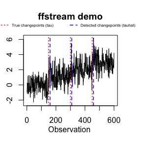

```r
library(ffstream)
result <- demo_ffstream(showPlot=TRUE, plotSmall=TRUE) #'plotSmall' only needed for vignette
```

Here, the **true** changepoints, labelled `tau`, are shown as the vertical red dotted lines, while the detected (estimated) changepoints, labelled `tauhat`, are shown as blue dashed lines. Note that the `showPlot=TRUE` flag is optional. The values are contained in the `result` list:

```r
print(result)
```

```
## $tau
## [1] 150 300 450
##
## $tauhat
## [1] 160 309 459
##
## $method
## [1] "AFF"
##
## $param
##   alpha   eta BL
## 1  0.01 0.001 50
```

It is also possible to return the vector of observations as part of the `result` list by using the `returnStream` flag:

```r
result <- demo_ffstream(returnStream=TRUE)
```

## Quick start

Here is a quick example of how to use the AFF method to detect a change in a vector of observations:

```r
#a simple stream with changepoints at tau=100, 200, 300
set.seed(5)
x <- rnorm(400, 0, 1) + rep(c(0:3), each=100)

#use the AFF method to detect changepoints in this stream
library(ffstream)
result <- detectAFFMean(x)
print(result)
```

```
## $tauhat
## [1] 113 206 303 382
```

In this example,

- the first three changepoints `tauhat=113, 206, 303` could be considered **correct** detections,
- but the last value, `tauhat=382` is a **false** detection, since there is no changepoint after `300`.

The rest of the vignette describes the many different options available for the change detectors: multiple or single changes, using known prechange means and variances, sequential or batch processing, etc.

## Implementation

The implementation in R uses the [(Rcpp package)](https://CRAN.R-project.org/package=Rcpp) to allow the core code to be written in C++. There are two ways to call the change detectors implemented here:

- initialise and sequentially update
- detect a change in a vector of observations (but still process observations sequentially)

# Initialise and sequentially update

This is the scenario for which the methods were designed; monitoring a data stream of observations, and as each observation arrives, the detector is (sequentially) updated.

## Initialisation

Initialising a change detector object is very easy. Here are four examples below:

```r
library(ffstream)

# initialise an AFF change detector with alpha=0.01, eta=0.001 and burn-in length 30
affcd <- initAFFMeanCD(alpha=0.01, eta=0.001, BL=30)

# initialise a FFF change detector with lambda=0.99, alpha=0.05, and burn-in length 50
fffcd <- initFFFMeanCD(lambda=0.99, alpha=0.05, BL=50)

# initialise a 'CUSUM' change detector with h=0.50, k=4.77, and burn-in length 70
cusumcd <- initCUSUMMeanCD(h=0.50, k=4.77, BL=70)

# initialise a 'EWMA' change detector with r=0.25, L=3.023, and burn-in length 50
ewmacd <- initEWMAMeanCD(r=0.25, L=3.023, BL=50)
```

## Updating sequentially

Updating is also easy (the syntax is the same for all detectors, so only the AFF method is shown):

```r
#generate an observation
x <- rnorm(1, mean=0, sd=1)

#update the detector
affcd$update(x)

#generate another observation
x <- rnorm(1, mean=0, sd=1)

#update the detector
affcd$update(x)

#etc...
```

### Sequentially processing a vector

Alternatively, one can sequentially process a vector using a for-loop:

```r
#generate a simple stream - same as in the 'Quick start' example above
set.seed(5)
x <- rnorm(400, 0, 1) + rep(c(0:3), each=100)

#initialise a new aff change detector object
affcd2 <- initAFFMeanCD(alpha=0.01, eta=0.01, BL=50)

index <- 0
for (obs in x){
    affcd2$update(obs)

    index <- index + 1
    if (affcd2$changeDetected)
        cat("change detected at observation: ", index, "\n", sep="")
}
```

```
## change detected at observation: 113
## change detected at observation: 206
## change detected at observation: 303
## change detected at observation: 382
```

The changepoints detected (`tauhat`) in this example are the same as in the *Quick start* example above, because the same stream was used, and the AFF was initialised with the same parameters (`alpha=0.01` and `eta=0.01` are the default values).

The example shows a field that each change detector has:

- `changeDetected` is a boolean which specifies if a change has just been detected after the most recent update.
- After detecting a change, in a multiple change detection scenario the detector will immediately switch to a *burn-in* state where it estimates the mean and variance of the stream.

# Detecting changes in vectors

As the example in the *Quick start* section shows, instead of initialising a detector object and sequentially updating as in the section above, it is also possible to process a vector directly. The following four methods are available:

- `detectAFFMean`
- `detectFFFMean`
- `detectCUSUMMean`
- `detectEWMAMean`

It is important to note that each method requires different control parameters, as shown in the examples below.

## Three modes of detection

There are also three modes for each detector:

- detect **multiple** changepoints, using a burn-in period to estimate the mean and variance for each new regime,
- detect a **single** changepoint, using a burn-in period to estimate the mean and variance for the first regime,
- detect a **single** changepoint, but use the known prechange mean and variance values (if known).

Althought the multiple changepoint case is perhaps the most interesting, the single changepoint option is available, since it is the case most often considered in the literature.

## Examples

```r
#generate a simple stream - same as in the 'Quick start' example above
set.seed(8)
x <- rnorm(400, 5, 1) + rep(c(0:3), each=100) # mean is 5 and s.d. is 1

#multiple changepoints
list_aff <- detectAFFMean(x, alpha=0.01, eta=0.01, BL=50, multiple=TRUE)

#now only a single (the first) changepoint
list_aff2 <- detectAFFMean(x, alpha=0.01, eta=0.01, BL=50, single=TRUE)

#now only a single (the first) changepoint, but with the prechange mean and variance known
list_aff3 <- detectAFFMean(x, alpha=0.01, eta=0.01, single=TRUE, prechangeMean=5, prechangeSigma=1)


#similar for FFF, 'CUSUM' and EWMA:
list_fff <- detectFFFMean(x, alpha=0.01, lambda=0.95, BL=50, multiple=TRUE)
list_cusum <- detectCUSUMMean(x, k=0.25, h=8.00, BL=50, multiple=TRUE)
list_ewma <- detectEWMAMean(x, r=0.25, L=3.023, BL=50, multiple=TRUE)

resultsList <- list("aff"=list_aff$tauhat, "fff"=list_fff$tauhat,
                    "cusum"=list_cusum$tauhat, "ewma"=list_ewma$tauhat,
                    "aff_single"=list_aff2$tauhat, "aff_single_prechange"=list_aff3$tauhat)

print(resultsList)
```

```
## $aff
## [1] 117 212 313
##
## $fff
## [1] 116 212 313
##
## $cusum
## [1] 115 213 310
##
## $ewma
## [1] 115 307
##
## $aff_single
## [1] 117
##
## $aff_single_prechange
## [1] 117
```

This example shows that, for this simple case, the detectors can have very similar detection performance.

# Further details: change detectors

This section provides a bit more information on how to use the change detector objects. Further information can be found by looking at the R documentation.

## Initialisation, Methods and fields

When **initialising** a change detector using either:

- `initAFFMeanCD`
- `initFFFMeanCD`
- `initCUSUMMeanCD`
- `initEWMAMeanCD`

then the following **methods** and are available to all:

- `update`: update the detector with a single observation,
- `processVectorSave`: batch process a vector of observations and return a list with the field `tauhat`, the estimated changepoints in that vector,
- `print`: print the current state of the detector.

The following **fields** are then available:

- `changeDetected`: a boolean specifying whether or not a change has been detected after the most recent observation,
- `streamEstMean`: the estimated mean of the stream; if a prechange value is known, it can be set (see examples below),
- `streamEstSigma`: the estimated standard deviation of the stream; if a prechange value is known (see examples below).

In practice, the most important method is `update`, and the most important field is `changeDetected`.

## Examples

```r
#generate a simple stream - same as in the 'Quick start' example above
set.seed(5)
x <- rnorm(400, 5, 3) + rep(c(0:3), each=100) # mean is 5 and s.d. is 3

#initialise a new aff change detector object
affcd3 <- initAFFMeanCD(alpha=0.01, eta=0.01, BL=50)

affcd3$streamEstMean <- 5
affcd3$streamEstSigma<- 3

#list containing tauhat, the estimated changepoints
returnList <- affcd3$processVectorSave(x)
```

# Adaptive estimation of the mean

Along with the four change detectors above, it is also possible to only compute the AFF and FFF means (i.e. no change detection).

## Initialisation

The two initialisation functions are which can be used to compute the AFF mean or the FFF mean.:

- `initAFFMean` which allows one to set the value of `eta` (default value `0.01`),
- `initFFFMean` which allows one set the value of `lambda` (default value `1`, i.e. no forgetting),

See [(Bodenham and Adams, 2016)](https://link.springer.com/article/10.1007/s11222-016-9684-8) for further details.

## Updating

The important methods in this case are:

- `update`: to sequentially update the mean,
- `processVector`: to batch update the mean by passing a vector,
- `processVectorSave`: (only for AFF) to batch update the mean AND return a vector of the adaptive forgetting factor $\overrightarrow{\lambda}$.

## Examples

```r
#initialise an AFF mean estimator
aff <- initAFFMean(eta=0.01) #it is not necessary to specify eta

#update sequentially
obs <- rnorm(1)
aff$update(obs)

#update with a vector
vec <- rnorm(20)
aff$processVector(vec)

#in order to get the value of the aff back:
aff <- initAFFMean(eta=0.01) #reset first
thelist <- aff$processVectorSave(vec)
lambda <- thelist$lambda

#initialise an FFF mean estimator
fff <- initFFFMean(lambda=0.95) #specify lambda, otherwise default is lambda=1, no forgetting
fff$processVector(vec)
```

Here is another example showing the behaviour of the AFF before/after a changepoint:

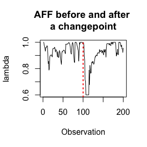

```r
aff <- initAFFMean(eta=0.01)

#create a stream
set.seed(7)
x <- rnorm(200) + rep(c(0, 2), each=100)

#lambda
thelist <- aff$processVectorSave(x)

titlestr <- "AFF before and after \na changepoint"
plot(thelist$lambda, type='l', col="black", xlab="Observation", ylab="lambda", main=titlestr)
abline(v=100, col="red", lty="dotted", lwd=2)
```

As the figure shows, the AFF is usually close to 1 (well, in the range [0.8, 1]) before the changepoint at `tau=100`, then drops dramatically — note that it is truncated at 0.6, for reasons explained in the paper — and then after a period of stability, it increases again. This is the typical, and desired, behaviour of the AFF.